# Relatório da Fase 01: Expressão Diferencial, Enriquecimento Funcional e Integração Transdiagnóstica

Pipeline RNA-seq Neurodegenerativo

2026-11-03

# 1. Introdução

## 1.1 Contexto e objetivo

As doenças de Alzheimer (AD), Huntington (HD) e Parkinson (PD) apresentam etiologias e manifestações clínicas distintas, mas compartilham processos relacionados à perda neuronal, alterações gliais, resposta imune e disfunção de circuitos neurais. A disponibilidade de dados públicos de RNA-seq permite investigar esses componentes de forma comparativa e testar se alterações transcriptômicas observadas em doenças distintas convergem para genes, processos biológicos ou vias moleculares comuns.

A **Fase 01** deste projeto estabelece uma linha de base padronizada para três datasets públicos de bulk RNA-seq:

Datasets incluídos na Fase 01.

| Código | GEO | Doença | Região |
| --- | --- | --- | --- |
| AD | GSE53697 | Doença de Alzheimer | Córtex pré-frontal dorsolateral |
| HD | GSE64810 | Doença de Huntington | BA9 / córtex pré-frontal |
| PD | GSE68719 | Doença de Parkinson | BA9 / córtex pré-frontal |

O objetivo foi analisar cada estudo independentemente e, em seguida, realizar uma integração transdiagnóstica em três níveis complementares:

1. **genes diferencialmente expressos**;
2. **direção e magnitude dos efeitos de expressão**;
3. **processos biológicos e vias funcionalmente enriquecidas**.

A estratégia foi deliberadamente construída para evitar que a integração dependesse apenas da interseção de listas discretas de DEGs, uma vez que estudos com tamanhos amostrais, variabilidade e poder estatístico diferentes podem compartilhar alterações funcionais mesmo quando não compartilham genes individualmente significativos.

# 2. Metodologia

## 2.1 Dados de entrada

Nesta fase foram utilizadas **matrizes de contagens brutas**, sem reprocessamento a partir de FASTQ.

Para AD (GSE53697), foi utilizada a matriz suplementar original `GSE53697_RNAseq_AD.txt.gz`. O arquivo contém colunas de contagens brutas e RPKM; apenas as colunas terminadas em `_raw` foram utilizadas. As colunas RPKM foram excluídas da análise de expressão diferencial.

Para HD (GSE64810) e PD (GSE68719), foram utilizadas as matrizes de contagens brutas geradas/disponibilizadas pelo NCBI GEO para cada série.

As análises foram realizadas separadamente por dataset. Os valores absolutos de expressão não foram concatenados nem comparados diretamente entre estudos.

## 2.2 Auditoria das matrizes

A etapa `00_audit_raw_data.R` verificou:

- dimensões das matrizes;
- número de amostras;
- presença de valores ausentes;
- valores negativos;
- valores não inteiros;
- proporção de zeros;
- genes totalmente zerados;
- integridade e unicidade dos NCBI GeneIDs;
- sobreposição do universo gênico entre os estudos;
- cobertura da anotação GRCh38.p13.

A auditoria mostrou que HD e PD continham apenas contagens inteiras. Em AD foram identificados valores fracionários na coluna de contagens brutas. Como o fluxo padrão do DESeq2 requer contagens inteiras, esses valores foram arredondados para o inteiro mais próximo exclusivamente durante a preparação da matriz, mantendo-se o arquivo bruto original inalterado.

## 2.3 Metadados

Os metadados foram reconstruídos a partir dos arquivos SOFT de cada série e padronizados em uma estrutura comum contendo identificador da amostra, grupo diagnóstico e covariáveis disponíveis.

Distribuição das amostras por dataset e grupo diagnóstico.

| dataset | group | n |
| --- | --- | --- |
| GSE53697 | AD | 9 |
| GSE53697 | Control | 8 |
| GSE64810 | Control | 49 |
| GSE64810 | HD | 20 |
| GSE68719 | Control | 44 |
| GSE68719 | PD | 29 |

O conjunto final incluiu:

- AD: 17 amostras — 8 controles e 9 casos;
- HD: 69 amostras — 49 controles e 20 casos;
- PD: 73 amostras — 44 controles e 29 casos.

O modelo principal de expressão diferencial utilizou apenas o grupo diagnóstico (`~ group`). Covariáveis clínicas não foram adicionadas silenciosamente ao modelo principal.

## 2.4 Preparação das contagens

O script `02_prepare_counts.R` gerou matrizes contendo apenas:

- NCBI GeneID;
- contagens brutas por amostra.

Nenhum gene foi removido nessa etapa.

Para AD, os valores fracionários foram arredondados para o inteiro mais próximo. Para HD e PD, os valores foram preservados numericamente.

## 2.5 Harmonização gênica

A harmonização foi realizada utilizando **NCBI GeneID como identificador principal**, uma vez que os três conjuntos de contagens utilizam esse identificador e a anotação Ensembl não cobre integralmente o universo de genes presente nas matrizes.

Foram preservados, quando disponíveis:

- NCBI GeneID;
- símbolo;
- Ensembl ID;
- tipo gênico;
- símbolo original do estudo de AD.

A harmonização identificou 39.620 GeneIDs na união das três matrizes e 18.941 GeneIDs presentes simultaneamente nos três conjuntos brutos. Esses valores representam o universo bruto e não o universo final testável após pré-filtragem.

## 2.6 Controle de qualidade e pré-filtragem

A pré-filtragem foi aplicada **somente ao ramo de expressão diferencial**.

O critério adotado foi:

$$\mathrm{count} \ge 10$$

em um número de amostras equivalente ao tamanho do menor grupo experimental de cada dataset:

- AD: pelo menos 8 amostras;
- HD: pelo menos 20 amostras;
- PD: pelo menos 29 amostras.

A estratégia foi aplicada independentemente a cada estudo.

Resumo da pré-filtragem de genes utilizada na análise de expressão diferencial.

| dataset | analysis_type | n_samples | min_group_size | min_count | min_samples_sensitivity | genes_before | genes_all_zero | genes_retained | genes_removed | percent_retained |
| --- | --- | --- | --- | --- | --- | --- | --- | --- | --- | --- |
| AD | selected | 17 | 8 | 10 | NA | 19185 | 574 | 15811 | 3374 | 82.413 |
| HD | selected | 69 | 20 | 10 | NA | 39376 | 1692 | 22093 | 17283 | 56.108 |
| PD | selected | 73 | 29 | 10 | NA | 39376 | 1870 | 21322 | 18054 | 54.150 |
| AD | sensitivity | NA | 8 | 5 | 8 | 19185 | NA | 16482 | 2703 | 85.911 |
| AD | sensitivity | NA | 8 | 10 | 8 | 19185 | NA | 15811 | 3374 | 82.413 |
| AD | sensitivity | NA | 8 | 20 | 8 | 19185 | NA | 15081 | 4104 | 78.608 |
| HD | sensitivity | NA | 20 | 5 | 20 | 39376 | NA | 24378 | 14998 | 61.911 |
| HD | sensitivity | NA | 20 | 10 | 20 | 39376 | NA | 22093 | 17283 | 56.108 |
| HD | sensitivity | NA | 20 | 20 | 20 | 39376 | NA | 19959 | 19417 | 50.688 |
| PD | sensitivity | NA | 29 | 5 | 29 | 39376 | NA | 23472 | 15904 | 59.610 |
| PD | sensitivity | NA | 29 | 10 | 29 | 39376 | NA | 21322 | 18054 | 54.150 |
| PD | sensitivity | NA | 29 | 20 | 29 | 39376 | NA | 19319 | 20057 | 49.063 |

Após a pré-filtragem, permaneceram:

- **15.811 genes em AD**;
- **22.093 genes em HD**;
- **21.322 genes em PD**.

Dos 18.941 GeneIDs originalmente comuns aos três estudos, **15.149 permaneceram após a pré-filtragem em todos os datasets**, correspondendo a aproximadamente 79,98% do universo comum bruto.

## 2.7 PCA

Para avaliação exploratória da estrutura global das amostras, as matrizes pré-filtradas foram transformadas por **variance stabilizing transformation (VST)** do DESeq2.

A VST foi utilizada apenas para visualização e controle de qualidade. A análise de expressão diferencial permaneceu baseada nas contagens inteiras.

Nenhuma amostra foi removida automaticamente com base apenas na posição no PCA.

## 2.8 Expressão diferencial com DESeq2

A expressão diferencial foi analisada separadamente em AD, HD e PD utilizando DESeq2, com modelo:

$$\mathrm{counts} \sim \mathrm{group}$$

O grupo controle foi utilizado como referência e o contraste foi definido como:

$$\mathrm{Disease} - \mathrm{Control}$$

Assim:

- `log2FoldChange > 0`: maior expressão na doença;
- `log2FoldChange < 0`: menor expressão na doença.

O teste principal do DESeq2 avaliou a hipótese nula padrão de `log2FoldChange = 0`. O limiar de efeito não foi incorporado ao teste estatístico, sendo utilizado posteriormente para classificação dos DEGs.

### Critério principal

$$\mathrm{padj}<0,05$$

e

$$|\log_2FC|>0,58$$

O limiar `|log2FC| > 0,58` corresponde aproximadamente a uma diferença de 1,5 vez na expressão.

### Análise de sensibilidade

$$\mathrm{padj}<0,05$$

e

$$|\log_2FC|>1$$

Essa análise utiliza um limiar de efeito mais restritivo, correspondente a aproximadamente duas vezes de diferença, mantendo a correção por múltiplos testes.

## 2.9 Enriquecimento funcional

Foram utilizadas duas estratégias complementares.

### ORA — Over-Representation Analysis

A ORA foi aplicada aos DEGs do critério principal, separando:

- todos os DEGs (`All`);
- genes aumentados (`Up`);
- genes reduzidos (`Down`).

Foram analisados:

- GO Biological Process;
- KEGG.

O universo da ORA foi composto pelos genes efetivamente testados pelo DESeq2 em cada dataset.

Como AD não apresentou DEGs pelo critério principal, sua ORA foi corretamente omitida.

### GSEA

O GSEA utilizou todos os genes com estatística de Wald válida, ranqueados pela variável `stat` produzida pelo DESeq2.

Foram analisados:

- GO Biological Process;
- KEGG.

No contraste doença-controle:

- `NES > 0` indica enriquecimento na extremidade positiva do ranking;
- `NES < 0` indica enriquecimento na extremidade negativa do ranking.

O NES não deve ser interpretado automaticamente como ativação ou inibição fisiológica de uma via.

## 2.10 Integração transdiagnóstica

A integração foi conduzida utilizando **universos de comparação definidos de acordo com a pergunta analítica**, evitando misturar ausência de teste com ausência de efeito.

Para as análises envolvendo simultaneamente AD, HD e PD, foi utilizado o **universo comum testável**, definido pela interseção dos genes com `p-value` e `log2FoldChange` válidos nos três datasets:

$$U_{AD,HD,PD}=U_{AD}\cap U_{HD}\cap U_{PD}$$

Esse universo foi utilizado para comparar a classificação de DEG entre as três doenças e para avaliar concordância direcional transdiagnóstica.

Para a comparação específica entre HD e PD, foi construído um **universo pareado**:

$$U_{HD,PD}=U_{HD}\cap U_{PD}$$

Dessa forma, um gene testável em HD e PD não é excluído da comparação apenas por não estar presente ou testável em AD. As correlações de Spearman entre os `log2FoldChange` também foram calculadas em universos pareados (`AD∩HD`, `AD∩PD` e `HD∩PD`).

Foram produzidos três diagramas de Venn com objetivos distintos:

1. **Venn do universo comum — critério principal:** FDR < 0,05 e `|log2FC| > 0,58`, restrito aos genes testáveis nos três datasets;
2. **Venn do universo comum — análise de sensibilidade:** FDR < 0,05 e `|log2FC| > 1`, também restrito ao universo comum;
3. **Venn comparativo nominal (“article-like”):** `p < 0,05` e `|log2FC| > 1`, utilizando as listas completas de genes que satisfizeram esse critério em cada dataset, sem restringir previamente ao universo comum.

O terceiro Venn foi incluído para permitir comparação conceitual com a estratégia de interseção empregada no estudo comparativo de referência. Ele **não substitui o critério principal do presente trabalho**, pois utiliza significância nominal em vez de FDR.

Além da sobreposição de DEGs, foram integrados:

- magnitude e direção dos `log2FoldChange`;
- correlações de Spearman entre pares de doenças;
- concordância direcional dos DEGs compartilhados;
- termos GSEA significativos compartilhados;
- resultados de ORA compartilhados entre HD e PD.

A integração funcional foi considerada particularmente importante para AD, uma vez que a ausência de DEGs individuais após correção por múltiplos testes não impede a existência de alterações coordenadas em conjuntos gênicos.

# 3. Visão geral dos resultados

## 3.1 Resumo da expressão diferencial

Resumo da análise de expressão diferencial com DESeq2.

| Dataset | Amostras | Genes testados | FDR < 0,05 | DEGs principais | Up — principal | Down — principal | DEGs sensibilidade | Up — sensibilidade | Down — sensibilidade |
| --- | --- | --- | --- | --- | --- | --- | --- | --- | --- |
| AD | 17 | 15811 | 0 | 0 | 0 | 0 | 0 | 0 | 0 |
| HD | 69 | 22093 | 5370 | 2227 | 1239 | 988 | 689 | 444 | 245 |
| PD | 73 | 21322 | 9218 | 2801 | 1576 | 1225 | 531 | 358 | 173 |

Os três datasets apresentaram comportamentos distintos. AD não apresentou genes que satisfizessem simultaneamente FDR < 0,05 e `|log2FC| > 0,58`, enquanto HD e PD apresentaram assinaturas diferenciais robustas.

PD apresentou o maior número de DEGs pelo critério principal, enquanto HD manteve maior número de DEGs quando aplicado o limiar mais restritivo de `|log2FC| > 1`.

# 4. Resultados — Alzheimer

## 4.1 PCA

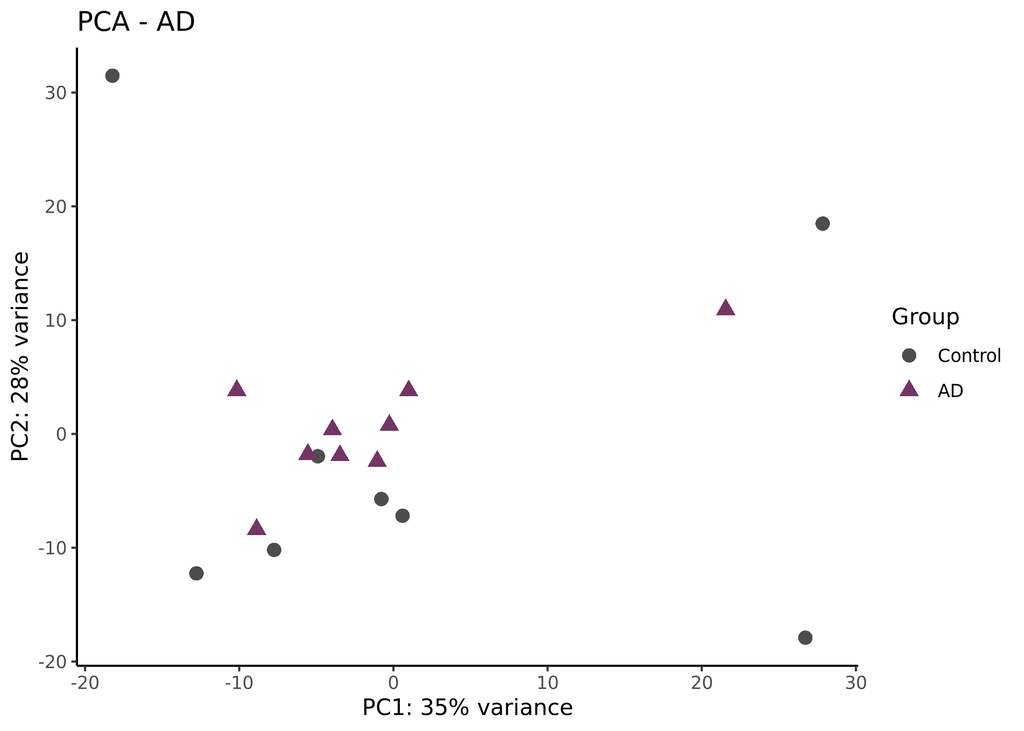

PCA das amostras do dataset de Alzheimer após VST.

Os dois primeiros componentes principais explicaram **63% da variabilidade observada** (`PC1 = 35%`; `PC2 = 28%`).

Observou-se ampla sobreposição entre casos e controles, sem separação global clara entre os grupos. Algumas amostras ocuparam regiões periféricas do espaço definido pelos dois primeiros componentes, porém nenhuma foi excluída com base apenas no PCA.

A elevada proporção de variância explicada por PC1 e PC2 não implica que 63% da variabilidade seja causada pelo diagnóstico. O PCA mostra a estrutura global da expressão, e a forte sobreposição entre casos e controles indica que outras fontes de variação também contribuem substancialmente para o dataset.

## 4.2 Expressão diferencial

AD apresentou **0 DEGs** pelo critério principal.

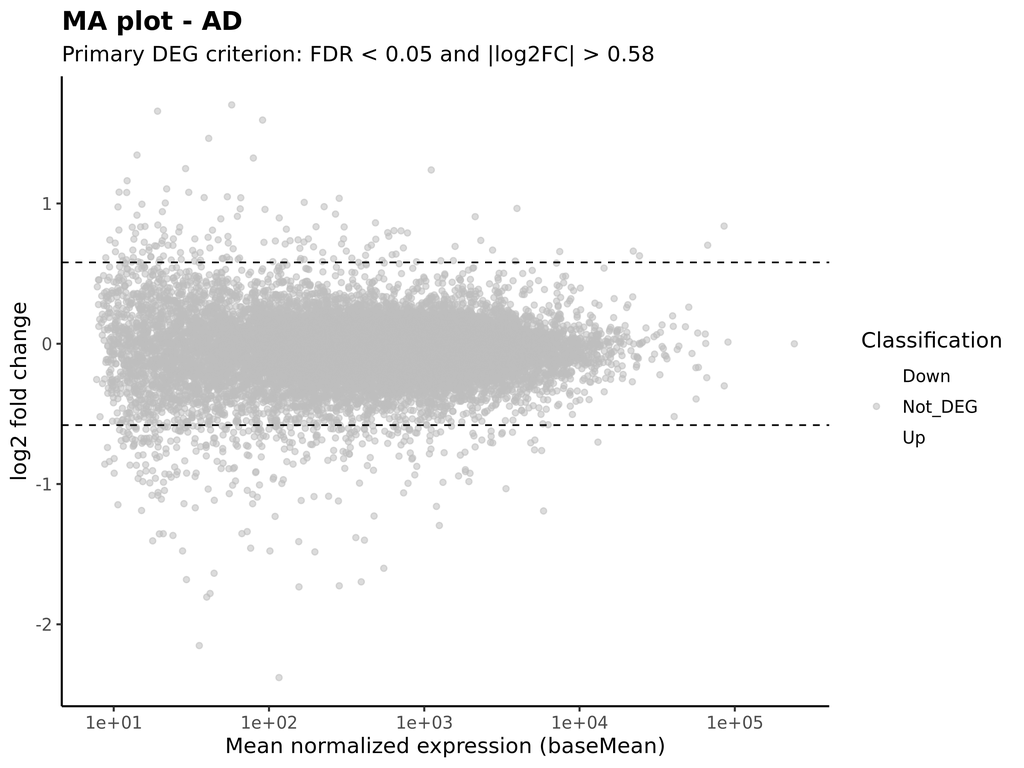

MA plot da análise de expressão diferencial em Alzheimer.

O MA plot mostra genes com diferentes magnitudes de `log2FoldChange`, porém nenhum ponto foi classificado como DEG pelo critério principal após correção por múltiplos testes.

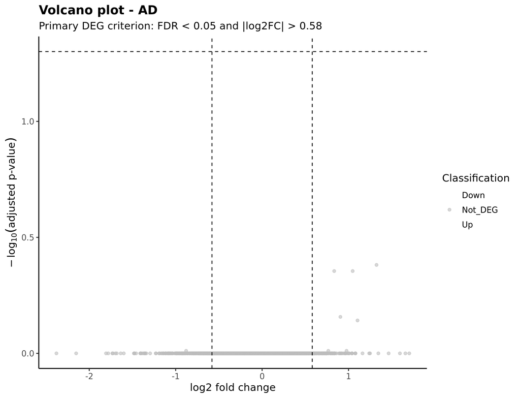

Volcano plot da análise de expressão diferencial em Alzheimer.

O volcano plot evidencia que o principal limitante em AD não foi a completa ausência de efeitos de expressão, mas a ausência de genes capazes de atingir FDR < 0,05 após correção por múltiplos testes.

Esse resultado foi mantido como parte da análise, sem relaxamento posterior do limiar de FDR para produzir artificialmente uma lista de DEGs.

## 4.3 Heatmap

Não foi produzido heatmap baseado nos DEGs principais para AD, pois nenhum gene atingiu o critério principal de significância. A ausência da figura é, portanto, consequência direta do resultado estatístico e não uma falha do pipeline.

## 4.4 Nota sobre a auditoria específica de AD

A discrepância entre a ausência de DEGs por FDR e resultados previamente descritos para GSE53697 motivou uma auditoria adicional.

A matriz bruta original foi comparada com a matriz preparada, confirmando identidade dos GeneIDs e das 17 colunas de contagens brutas. As colunas RPKM foram excluídas corretamente, e o arredondamento aplicado antes do DESeq2 alterou apenas os valores fracionários, com diferença máxima individual de 0,5.

Também foi realizada uma análise exploratória utilizando significância nominal. O dataset apresentou genes com `p < 0,05` e efeitos de expressão relevantes, mas esses sinais não permaneceram significativos após correção para múltiplos testes.

Assim, o resultado de zero DEGs deve ser interpretado como **ausência de genes individualmente robustos sob os critérios estatísticos adotados neste pipeline**, e não como ausência de qualquer estrutura biológica no dataset.

## 4.5 GSEA — GO Biological Process

AD apresentou **133 termos GO BP significativos** por GSEA.

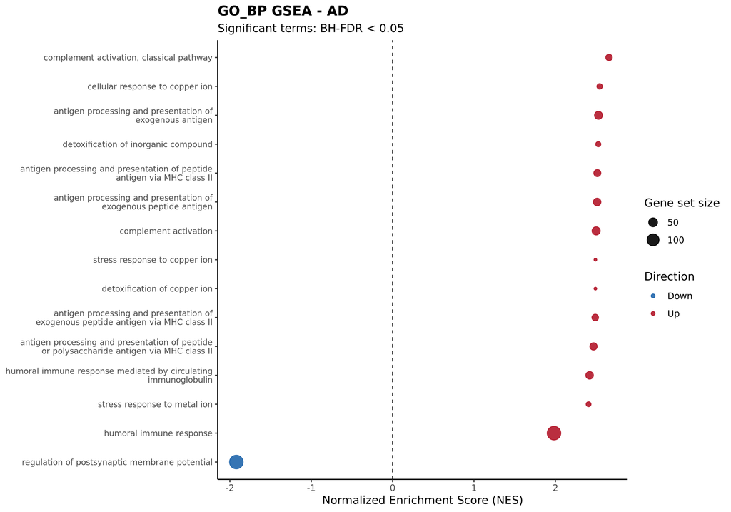

GSEA de Gene Ontology Biological Process no dataset de Alzheimer.

Entre os termos positivos destacaram-se processos relacionados a:

- ativação do sistema complemento;
- resposta imune humoral;
- processamento e apresentação de antígenos;
- apresentação via MHC classe II;
- resposta celular e detoxificação relacionadas a cobre e outros metais.

Entre os termos negativos destacou-se a regulação do potencial de membrana pós-sináptica.

O resultado mostra que **ausência de DEGs individuais não equivale à ausência de alteração funcional coordenada**. O GSEA identifica deslocamentos consistentes de conjuntos de genes ao longo do ranking completo, mesmo quando cada gene isoladamente não alcança FDR < 0,05.

## 4.6 GSEA — KEGG

AD apresentou **42 vias KEGG significativas**.

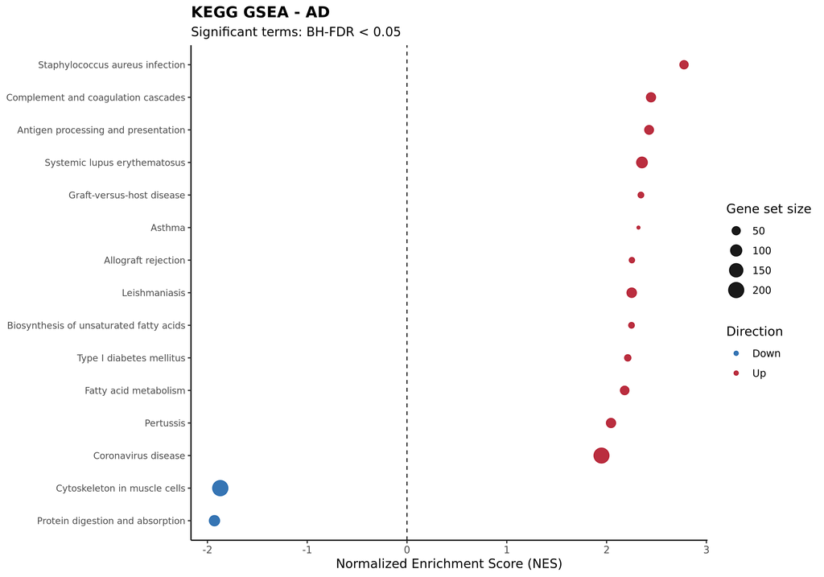

GSEA de vias KEGG no dataset de Alzheimer.

Foram observados enriquecimentos positivos para vias relacionadas a:

- complemento e coagulação;
- processamento e apresentação de antígenos;
- metabolismo de ácidos graxos;
- módulos imunes compartilhados com diferentes categorias infecciosas, autoimunes e inflamatórias.

Categorias KEGG nomeadas por doenças infecciosas ou autoimunes não foram interpretadas literalmente como presença dessas condições nas amostras. Essas vias compartilham genes de complemento, MHC, citocinas e outros componentes de resposta imune.

### Síntese — AD

**AD apresentou sinal fraco no nível de genes individuais, mas forte organização funcional.**  
O padrão predominante foi enriquecimento positivo de processos imunes, complemento e apresentação antigênica, acompanhado por enriquecimento negativo de processos relacionados à função pós-sináptica.

# 5. Resultados — Huntington

## 5.1 PCA

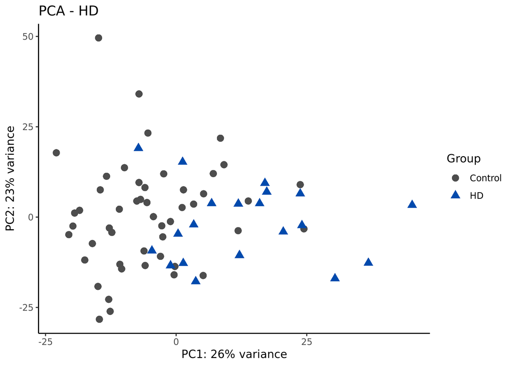

PCA das amostras do dataset de Huntington após VST.

Os dois primeiros componentes explicaram **49% da variância total** (`PC1 = 26%`; `PC2 = 23%`).

Observou-se separação parcial entre HD e controles, sobretudo ao longo de PC1, embora ainda exista sobreposição entre os grupos. Os controles também apresentaram dispersão considerável, compatível com heterogeneidade biológica e técnica de amostras humanas de tecido cerebral pós-morte.

## 5.2 Expressão diferencial

Foram identificados:

- **2.227 DEGs** pelo critério principal;
- **1.239 genes aumentados**;
- **988 genes reduzidos**.

Na análise de sensibilidade, permaneceram **689 DEGs**.

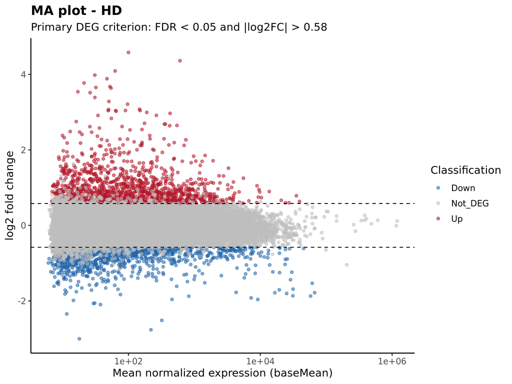

MA plot da análise de expressão diferencial em Huntington.

O MA plot mostrou ampla distribuição de alterações nas duas direções, com discreta predominância de genes aumentados e presença de alguns efeitos positivos de grande magnitude.

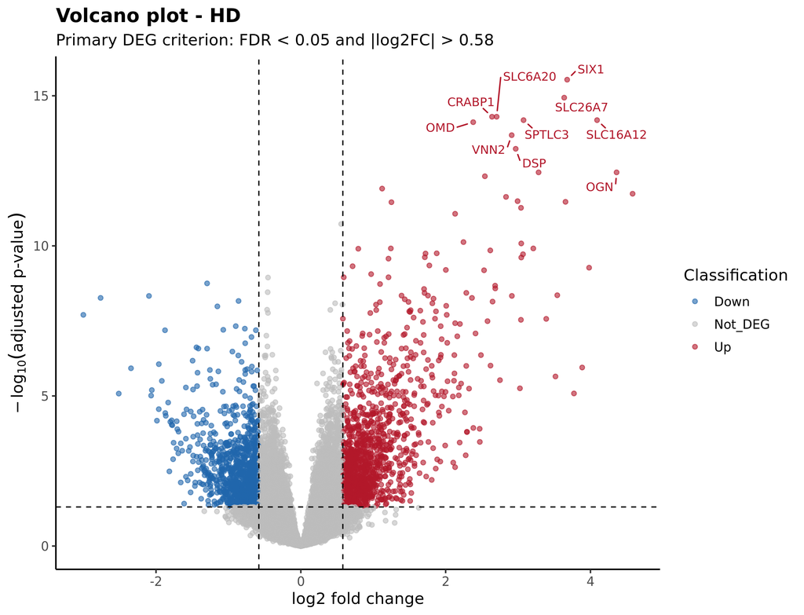

Volcano plot da análise de expressão diferencial em Huntington.

Entre os sinais de maior destaque visual apareceram genes como `SIX1`, `SLC6A20`, `CRABP1`, `OMD`, `VNN2`, `SPTLC3`, `DSP`, `OGN`, `SLC26A7` e `SLC16A12`.

Esses genes representam candidatos de alta significância e/ou magnitude de efeito, mas a interpretação mecanística deve considerar o conjunto funcional e não apenas genes isolados.

## 5.3 Heatmap dos 50 principais DEGs

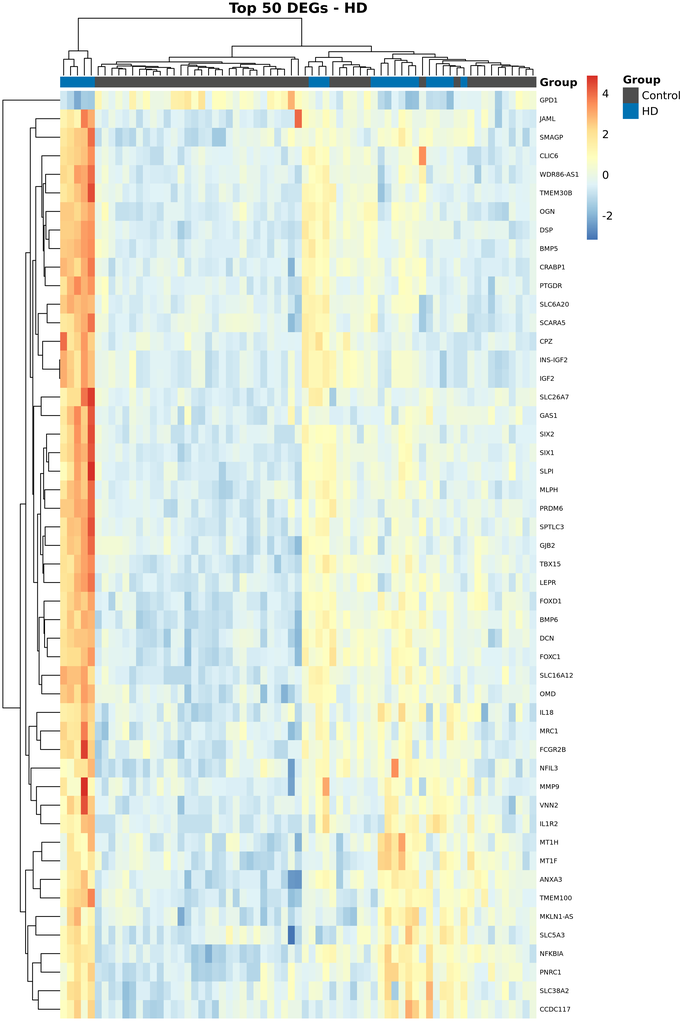

Heatmap dos 50 principais DEGs do dataset de Huntington.

O heatmap mostrou uma assinatura transcriptômica coerente, com tendência de separação entre HD e controles, embora não perfeita. Vários genes apresentaram menor expressão relativa nos controles e maior expressão nas amostras HD.

O agrupamento hierárquico reforça a presença de uma assinatura associada à doença, mas também evidencia heterogeneidade entre indivíduos.

## 5.4 ORA — GO Biological Process

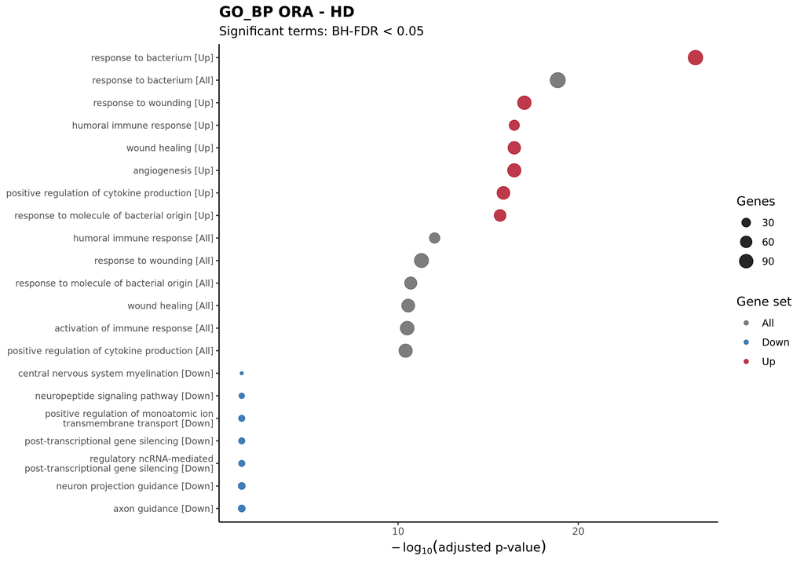

ORA de Gene Ontology Biological Process no dataset de Huntington.

Os genes aumentados foram enriquecidos principalmente para:

- resposta imune;
- resposta humoral;
- produção de citocinas;
- resposta a estímulos bacterianos;
- cicatrização;
- angiogênese.

Em contraste, os genes reduzidos foram enriquecidos para:

- mielinização do sistema nervoso central;
- sinalização por neuropeptídeos;
- transporte transmembrana de íons;
- orientação de projeções neuronais;
- orientação axonal.

Esse padrão estabelece um contraste entre **programas imunes/remodelamento aumentados** e **programas neuronais/mielínicos reduzidos**.

## 5.5 ORA — KEGG

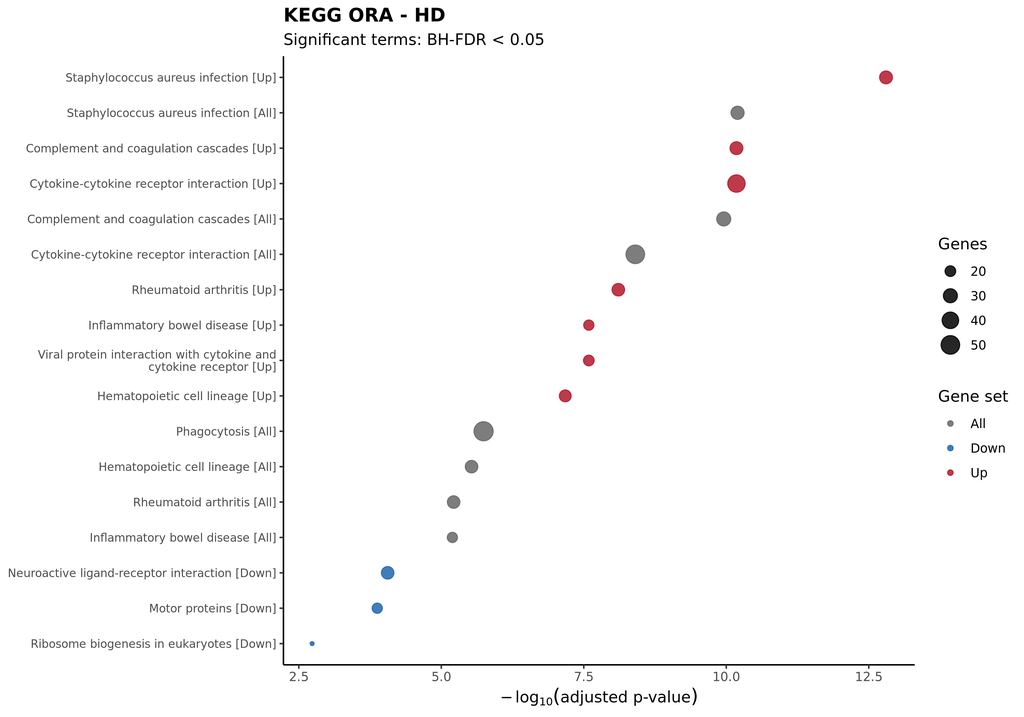

ORA de vias KEGG no dataset de Huntington.

Nos genes reduzidos destacaram-se:

- interação ligante–receptor neuroativo;
- proteínas motoras;
- biogênese ribossomal.

## 5.6 GSEA — GO Biological Process

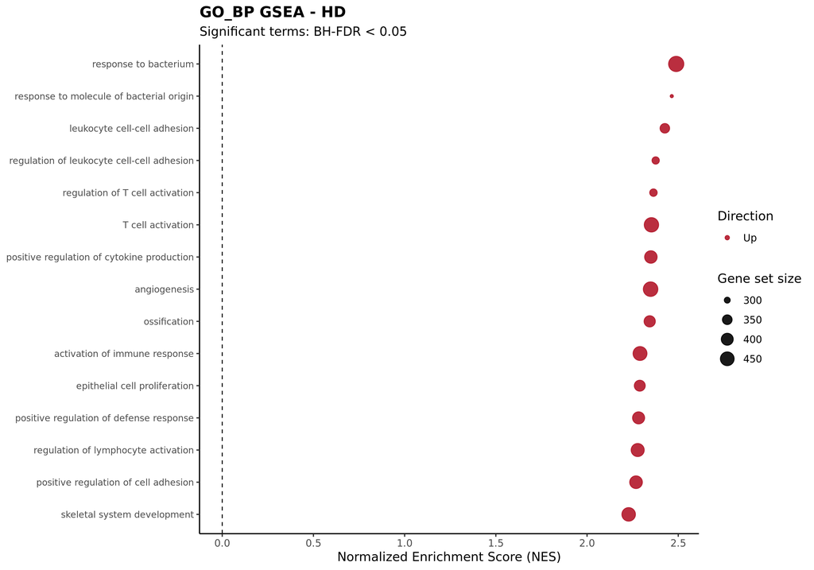

GSEA de Gene Ontology Biological Process no dataset de Huntington.

O GSEA confirmou enriquecimento positivo de processos relacionados à:

- ativação e regulação de células T;
- ativação de leucócitos;
- produção de citocinas;
- resposta de defesa;
- adesão celular;
- angiogênese.

A concordância entre GSEA e ORA fortalece a interpretação do eixo imunológico observado em HD.

## 5.7 GSEA — KEGG

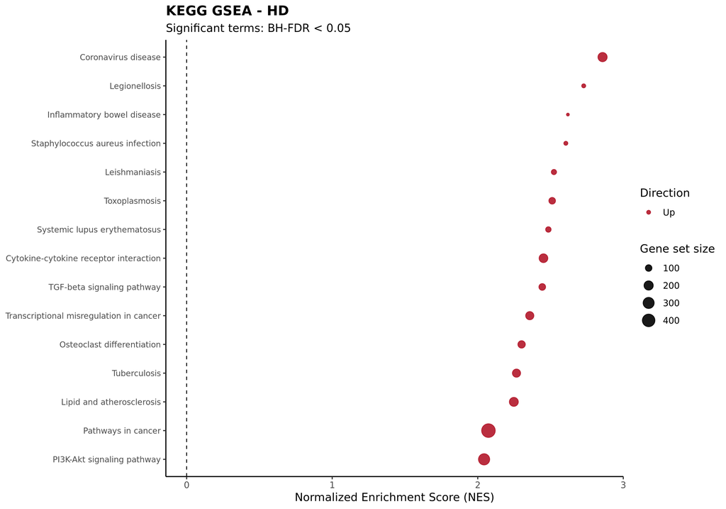

GSEA de vias KEGG no dataset de Huntington.

As vias positivas incluíram:

- interação citocina–receptor;
- TGF-β;
- PI3K-Akt;
- categorias inflamatórias e infecciosas que compartilham módulos imunes.

Essas categorias foram interpretadas pelo conteúdo gênico compartilhado, e não pelo nome literal da doença presente no banco KEGG.

### Síntese — HD

**HD apresentou uma assinatura diferencial robusta e bidirecional.**  
Os resultados convergiram para enriquecimento positivo de processos imunes/inflamatórios e remodelamento, acompanhado por redução de processos relacionados à mielinização, orientação axonal e comunicação neuronal.

# 6. Resultados — Parkinson

## 6.1 PCA

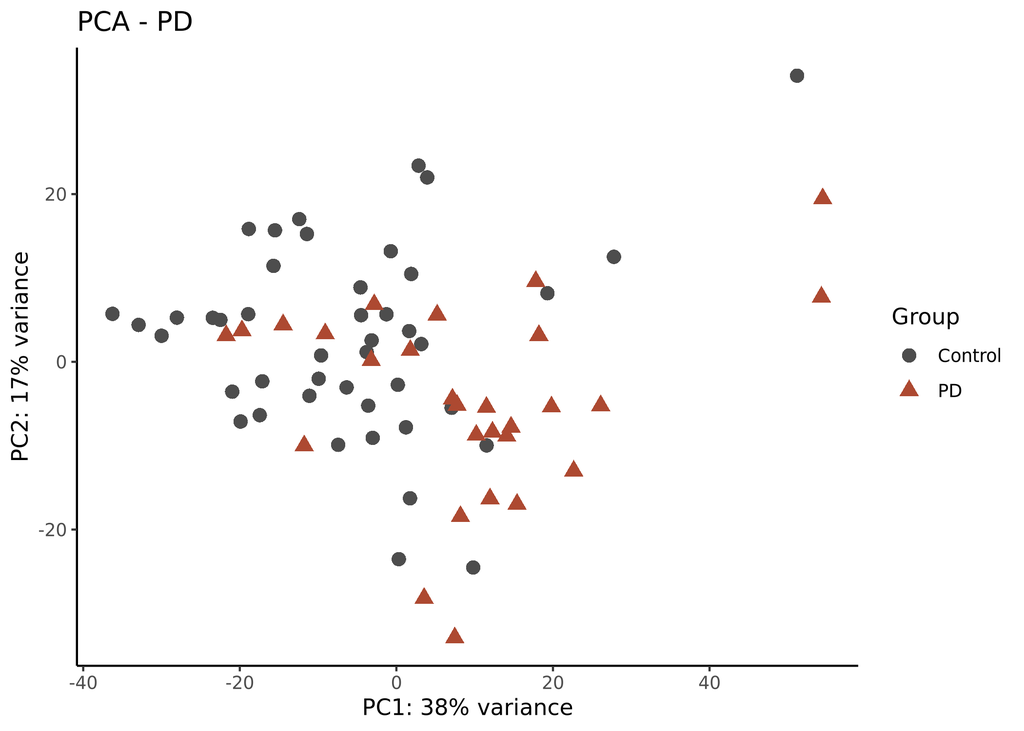

PCA das amostras do dataset de Parkinson após VST.

Os dois primeiros componentes explicaram **55% da variância total** (`PC1 = 38%`; `PC2 = 17%`).

Observou-se separação parcial entre casos e controles principalmente ao longo de PC1, embora com considerável sobreposição. Assim como em HD, a doença representa uma fonte relevante, mas não exclusiva, de variação transcriptômica.

## 6.2 Expressão diferencial

Foram identificados:

- **2.801 DEGs** pelo critério principal;
- **1.576 genes aumentados**;
- **1.225 genes reduzidos**.

Na análise de sensibilidade, permaneceram **531 DEGs**.

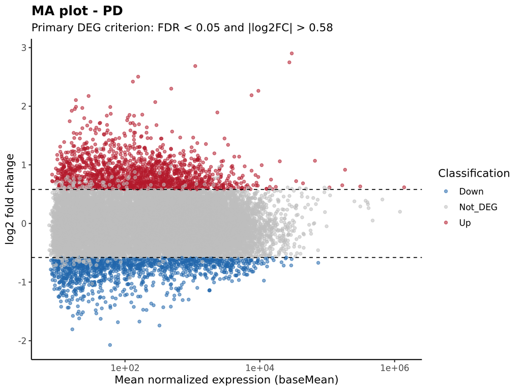

MA plot da análise de expressão diferencial em Parkinson.

O MA plot evidenciou numerosos genes significativos em ambas as direções ao longo de ampla faixa de expressão média.

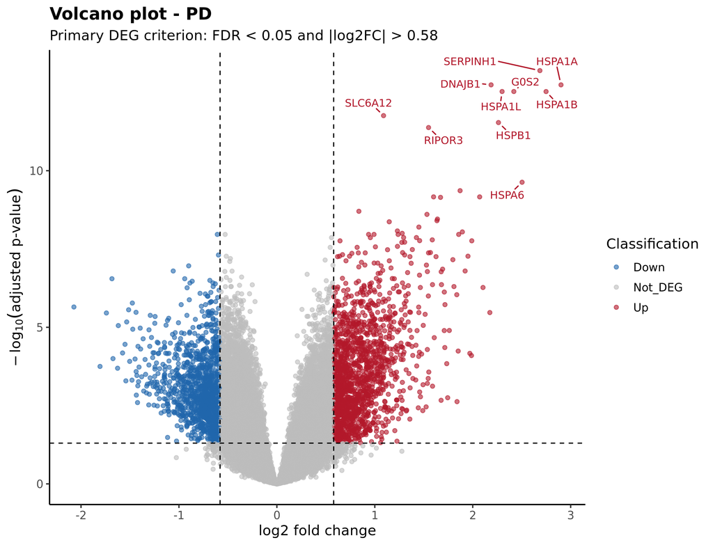

Volcano plot da análise de expressão diferencial em Parkinson.

Entre os genes de maior destaque visual apareceram `SERPINH1`, `HSPA1A`, `DNAJB1`, `GOS2`, `SLC6A12`, `HSPA1L`, `HSPA1B`, `HSPB1`, `RIPOR3` e `HSPA6`.

## 6.3 Heatmap dos 50 principais DEGs

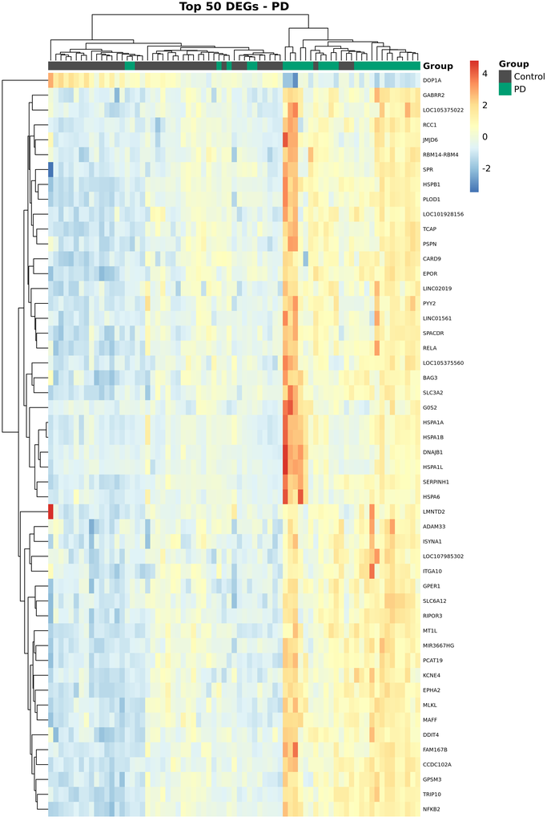

Heatmap dos 50 principais DEGs do dataset de Parkinson.

O heatmap mostrou uma assinatura transcriptômica coerente, com tendência de separação entre casos e controles e expressão coordenada de diversos genes associados à resposta celular e ao estresse.

## 6.4 ORA — GO Biological Process

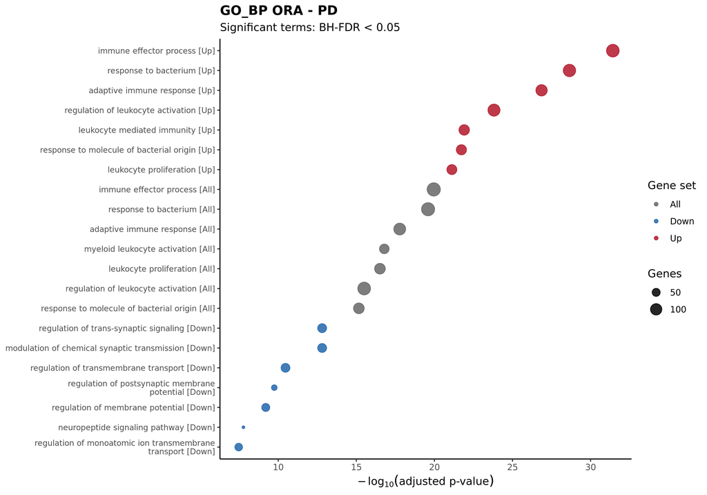

ORA de Gene Ontology Biological Process no dataset de Parkinson.

Os genes aumentados apresentaram forte enriquecimento para:

- resposta imune adaptativa;
- ativação de leucócitos;
- imunidade mediada por leucócitos;
- resposta a moléculas de origem bacteriana;
- processos efetores imunes.

Os genes reduzidos foram enriquecidos para:

- regulação da sinalização trans-sináptica;
- modulação da transmissão sináptica química;
- potencial de membrana;
- transporte iônico;
- sinalização por neuropeptídeos.

## 6.5 ORA — KEGG

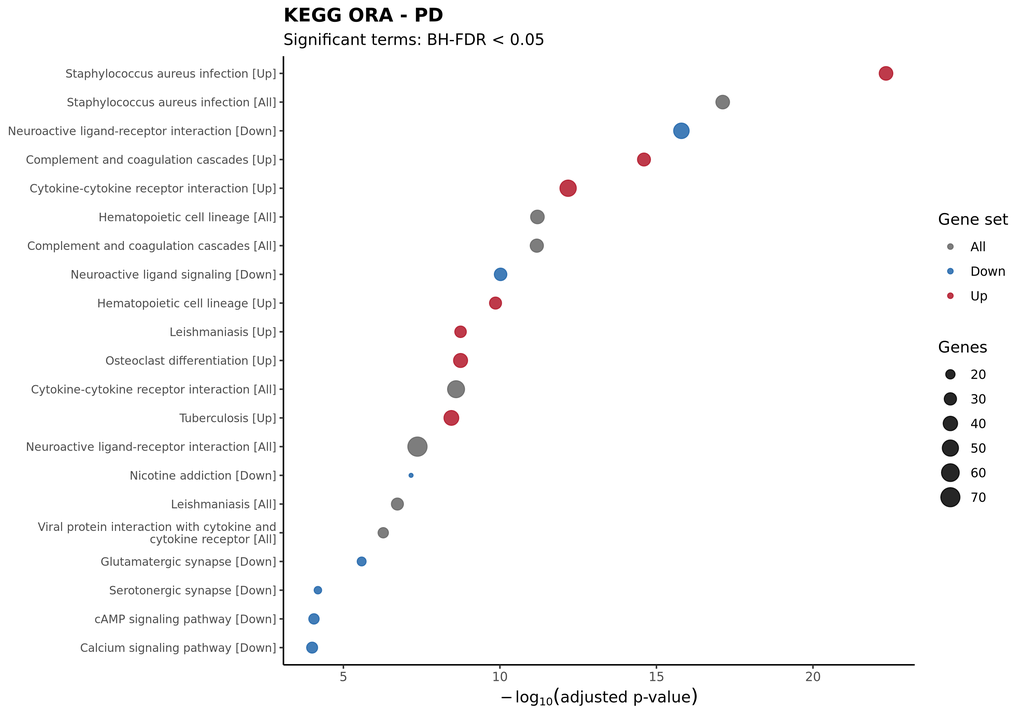

ORA de vias KEGG no dataset de Parkinson.

Os genes aumentados apresentaram enriquecimento para:

- interação citocina–receptor;
- complemento e coagulação;
- linhagem hematopoiética;
- categorias imunes/inflamatórias.

Nos genes reduzidos foram observadas:

- interação ligante–receptor neuroativo;
- sinapse glutamatérgica;
- sinapse serotoninérgica;
- sinalização por cálcio;
- sinalização por cAMP.

## 6.6 GSEA — GO Biological Process

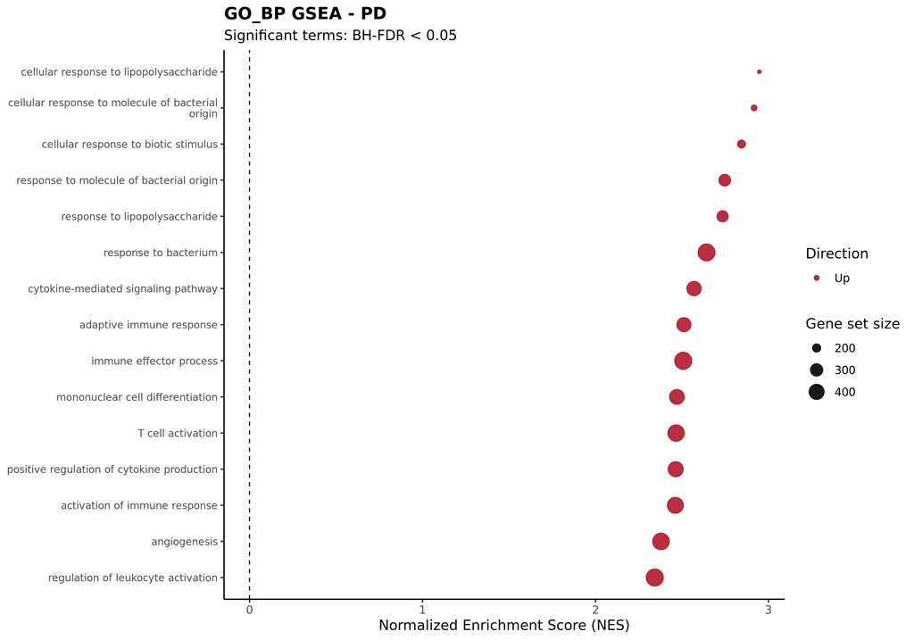

GSEA de Gene Ontology Biological Process no dataset de Parkinson.

O GSEA confirmou forte enriquecimento positivo de resposta imune, citocinas, resposta a lipopolissacarídeo, células T e ativação de leucócitos.

## 6.7 GSEA — KEGG

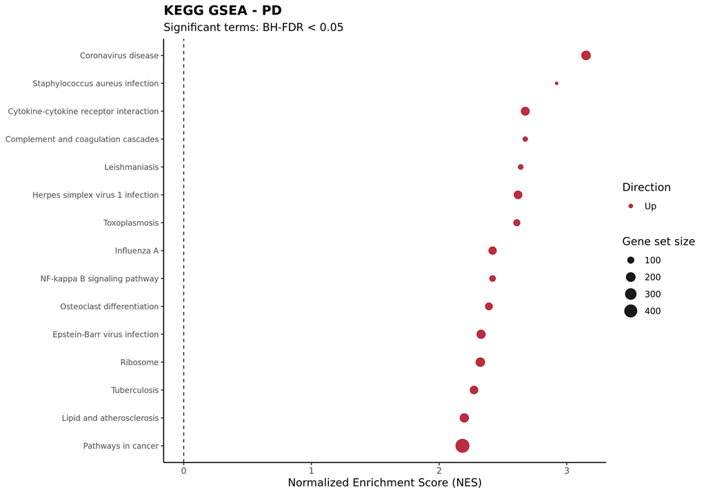

GSEA de vias KEGG no dataset de Parkinson.

Foram observados enriquecimentos positivos para:

- interação citocina–receptor;
- complemento e coagulação;
- sinalização por NF-κB;
- módulos imunes compartilhados por categorias infecciosas e inflamatórias.

### Síntese — PD

**PD apresentou a assinatura diferencial mais extensa pelo critério principal.**  
A análise funcional revelou um contraste claro entre enriquecimento imunoinflamatório positivo e redução de processos de neurotransmissão, potencial de membrana e sinalização neuronal.

# 7. Comparação entre AD, HD e PD

## 7.1 Expressão diferencial

Comparação da expressão diferencial entre os três datasets.

| Doença | Genes testados | DEGs principais | Up | Down | DEGs \|log2FC\| > 1 |
| --- | --- | --- | --- | --- | --- |
| AD | 15811 | 0 | 0 | 0 | 0 |
| HD | 22093 | 2227 | 1239 | 988 | 689 |
| PD | 21322 | 2801 | 1576 | 1225 | 531 |

Os três estudos apresentaram perfis distintos.

AD apresentou sinal estatístico fraco no nível de genes individuais, enquanto HD e PD apresentaram milhares de DEGs.

PD apresentou maior número de genes ultrapassando o limiar principal de `|log2FC| > 0,58`, enquanto HD reteve maior número de genes quando foi aplicado o limiar mais restritivo de `|log2FC| > 1`.

Essas diferenças não devem ser traduzidas diretamente como maior ou menor intensidade biológica de uma doença, pois os datasets diferem em tamanho amostral, variabilidade, características clínicas e estrutura técnica.

## 7.2 Comparação dos PCA

A porcentagem de variância explicada por PC1 + PC2 foi:

- AD: 63%;
- HD: 49%;
- PD: 55%.

Entretanto, variância explicada pelos componentes não equivale à variância explicada pelo diagnóstico.

AD apresentou a maior proporção de variância concentrada nos dois primeiros PCs, mas também a maior sobreposição visual entre casos e controles. HD e PD mostraram tendência mais evidente de separação ao longo de PC1.

## 7.3 Padrão funcional comparativo

Nas três doenças emergiu um eixo funcional recorrente:

$$\text{processos imunológicos/inflamatórios} \uparrow$$

em contraste com:

$$\text{processos neuronais/sinápticos} \downarrow$$

Esse padrão foi mais explícito em HD e PD, nos quais ORA e GSEA convergiram, mas também foi detectado em AD por GSEA mesmo na ausência de DEGs individuais.

# 8. Integração transdiagnóstica

## 8.1 Universo comum de genes testáveis

Para realizar comparações transdiagnósticas sem confundir **ausência de teste** com **ausência de significância estatística**, foi inicialmente definido um universo comum de genes testáveis.

Foram considerados testáveis os genes que apresentaram estimativas válidas de `log2FoldChange` e `p-value` nas análises de expressão diferencial de cada dataset.

A interseção dos universos testáveis de AD, HD e PD resultou em:

$$U_{AD}^{testável}
\cap
U_{HD}^{testável}
\cap
U_{PD}^{testável}
=
15.149
\text{ genes}$$

Portanto, **15.149 genes puderam ser diretamente comparados nas três doenças**.

Esse conjunto foi utilizado nas análises que exigiam comparabilidade simultânea entre AD, HD e PD.

É importante destacar que esse número **não representa genes diferencialmente expressos compartilhados entre as três doenças**. Ele representa apenas o conjunto de genes para os quais havia informação estatística disponível nos três datasets.

## 8.2 Distribuição dos DEGs no universo comum testável

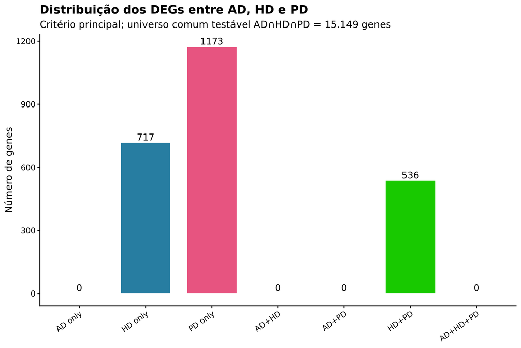

Distribuição dos DEGs identificados pelo critério principal no universo comum de genes testáveis entre AD, HD e PD.

Após restringir a análise aos **15.149 genes testáveis nas três doenças**, os genes diferencialmente expressos foram classificados de acordo com os datasets nos quais satisfizeram o critério principal:

$$FDR < 0,05
\quad \text{e} \quad
|\log_2FC| > 0,58$$

Foram identificados:

- **717 genes exclusivos de HD**;
- **1.173 genes exclusivos de PD**;
- **536 genes diferencialmente expressos simultaneamente em HD e PD**.

Nenhum gene foi classificado como DEG em AD pelo critério principal. Consequentemente, não foram observadas interseções envolvendo AD.

Assim, dentro do universo diretamente comparável entre as três doenças, a sobreposição gênica significativa ocorreu exclusivamente entre HD e PD.

Esse resultado deve ser distinguido dos totais completos de DEGs obtidos separadamente em cada dataset. O universo comum restringe a comparação apenas aos genes que puderam ser avaliados nas três doenças.

## 8.3 Análise de sensibilidade no universo comum

Para avaliar a robustez da sobreposição observada, foi aplicado um limiar de magnitude mais restritivo:

$$FDR < 0,05
\quad \text{e} \quad
|\log_2FC| > 1$$

mantendo o mesmo universo comum de genes testáveis.

Distribuição dos DEGs no universo comum testável utilizando o critério principal e a análise de sensibilidade.

| Categoria | Critério principal | Análise de sensibilidade |
| --- | --- | --- |
| HD exclusivo | 717 | 257 |
| PD exclusivo | 1173 | 200 |
| HD + PD | 536 | 100 |

Com o critério principal, foram observados 717 genes exclusivos de HD, 1.173 exclusivos de PD e 536 compartilhados entre HD e PD.

Com o limiar de sensibilidade, esses números foram reduzidos para 257 genes exclusivos de HD, 200 exclusivos de PD e 100 compartilhados entre HD e PD.

A redução é esperada, uma vez que o segundo critério exige alterações de maior magnitude.

Apesar dessa redução, a existência de uma interseção HD–PD foi preservada, indicando que parte da convergência transcriptômica entre as duas doenças permanece mesmo quando são considerados apenas efeitos mais fortes.

## 8.4 Interseção das listas completas — critério nominal comparativo

Para permitir uma comparação conceitualmente mais próxima daquela empregada no estudo comparativo de referência, foi realizada uma análise adicional utilizando o critério:

$$p < 0,05
\quad \text{e} \quad
|\log_2FC| > 1$$

Neste caso, foram utilizadas as **listas completas de genes que satisfizeram o critério em cada dataset**, sem restringir previamente a análise ao universo comum testável.

Essa estratégia é diferente da análise principal deste trabalho, pois utiliza significância nominal em vez de FDR.

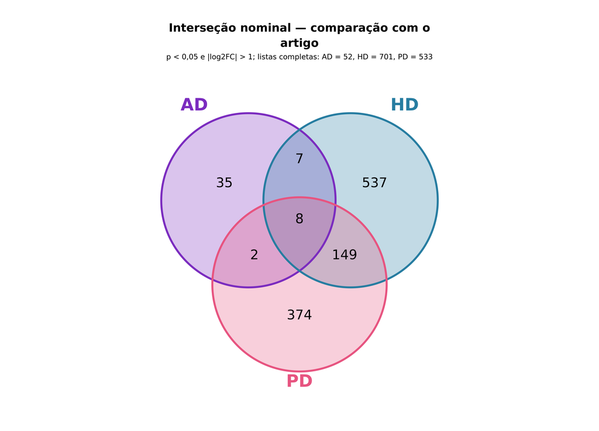

Interseção das listas completas de genes identificados com p < 0,05 e |log2FC| > 1 nos três datasets. Esse critério foi utilizado exclusivamente para comparação com a estratégia apresentada no artigo de referência.

As listas completas obtidas pelo nosso DESeq2 continham:

- AD: **52 genes**;
- HD: **701 genes**;
- PD: **533 genes**.

O diagrama mostrou 35 genes exclusivos de AD, 537 exclusivos de HD, 374 exclusivos de PD, 7 genes compartilhados apenas entre AD e HD, 2 compartilhados apenas entre AD e PD, 149 compartilhados apenas entre HD e PD e 8 genes presentes na interseção das três doenças.

Considerando também os oito genes da interseção tripla, o compartilhamento total foi de 157 genes entre HD e PD, 15 entre AD e HD e 10 entre AD e PD.

Novamente, a maior sobreposição ocorreu entre HD e PD.

### Comparação com o artigo

Comparação entre o critério nominal apresentado no artigo, o mesmo cutoff aplicado aos resultados do nosso DESeq2 e a análise de sensibilidade baseada em FDR.

| Dataset | Artigo: p<0,05 + \|log2FC\|>1 | Nosso DESeq2: p<0,05 + \|log2FC\|>1 | Nosso DESeq2: FDR<0,05 + \|log2FC\|>1 |
| --- | --- | --- | --- |
| AD | 262 | 52 | 0 |
| HD | 1581 | 701 | 689 |
| PD | 537 | 533 | 531 |

Embora o mesmo cutoff nominal tenha sido aplicado aos resultados do nosso DESeq2, isso **não torna as duas análises metodologicamente idênticas**, pois os pipelines de processamento e modelagem estatística são diferentes.

Ainda assim, a comparação é informativa. Para PD, o número de genes foi muito semelhante: 537 no artigo versus 533 no nosso DESeq2. Em HD, foram observados 1.581 genes no artigo e 701 no nosso processamento. A maior diferença ocorreu em AD, com 262 genes relatados no artigo e 52 identificados pelo nosso DESeq2 utilizando o mesmo cutoff nominal.

Apesar dessas diferenças quantitativas, a estrutura da interseção manteve maior compartilhamento entre HD e PD, e **oito genes foram compartilhados pelas três doenças no nosso resultado nominal**.

Essa análise deve ser considerada **comparativa e exploratória** e não substitui os resultados principais definidos por FDR.

## 8.5 Comparação pareada entre HD e PD

As análises anteriores mostraram que HD e PD apresentavam a maior convergência gênica.

Por esse motivo, foi realizada uma análise adicional específica entre essas duas doenças.

Diferentemente da integração simultânea AD–HD–PD, essa comparação não precisa ser limitada pelos genes disponíveis em AD.

Foi então definido o universo pareado:

$$U_{HD}^{testável}
\cap
U_{PD}^{testável}
=
21.308
\text{ genes}$$

Portanto, **21.308 genes puderam ser diretamente comparados entre HD e PD**.

Esse universo é maior que o universo triplo de 15.149 genes porque inclui genes testáveis em HD e PD mesmo quando eles não eram testáveis em AD.

### Concordância dos efeitos de expressão

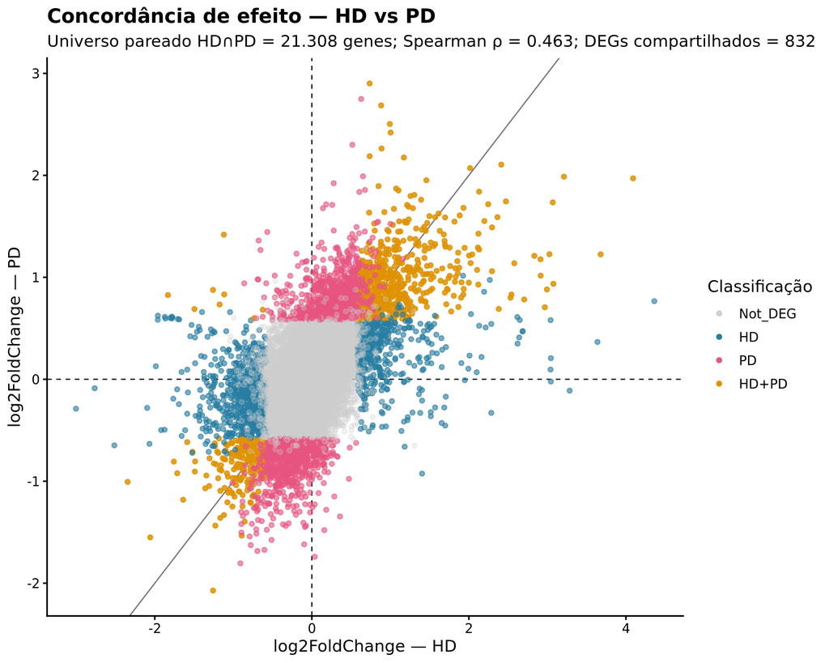

Relação entre os log2FoldChanges de HD e PD no universo pareado HD∩PD. As linhas tracejadas indicam log2FC = 0, enquanto a diagonal y=x representa igualdade de magnitude dos efeitos entre as duas doenças.

A correlação de Spearman entre os `log2FoldChange` de HD e PD foi:

$$\rho =
0,463$$

considerando:

$$n =
21.308$$

genes.

Esse resultado indica uma **associação positiva moderada entre os efeitos transcriptômicos das duas doenças**.

Genes com `log2FoldChange` de mesmo sinal aparecem predominantemente nos quadrantes superior direito e inferior esquerdo, enquanto genes com efeitos opostos ocupam os quadrantes restantes.

A linha diagonal `y = x` representa igualdade entre as magnitudes dos efeitos em HD e PD. A proximidade de um gene à diagonal indica efeitos quantitativamente semelhantes nas duas doenças, enquanto a distância indica diferenças de magnitude.

### DEGs compartilhados entre HD e PD

No universo pareado foram identificados:

$$832$$

genes classificados como DEGs tanto em HD quanto em PD.

Desses:

$$824$$

apresentaram a mesma direção de efeito, enquanto apenas:

$$8$$

apresentaram direções opostas.

Isso corresponde a aproximadamente:

$$99,0\%$$

dos DEGs compartilhados apresentando concordância direcional.

É importante distinguir esse resultado da correlação global.

A correlação de Spearman é calculada utilizando **todos os 21.308 genes do universo pareado**, incluindo genes com efeitos pequenos ou próximos de zero.

Já a concordância de direção de aproximadamente 99% refere-se apenas ao subconjunto de **832 genes classificados como DEGs nas duas doenças**.

Portanto, uma correlação global moderada pode coexistir com uma concordância direcional muito elevada entre os genes diferencialmente expressos compartilhados.

A diferença entre os **536 DEGs HD–PD observados no universo comum às três doenças** e os **832 DEGs compartilhados no universo pareado** decorre exclusivamente da definição do universo de comparação.

No primeiro caso, o gene precisava ser testável em AD, HD e PD. No segundo, precisava ser testável apenas em HD e PD.

### Correlação entre os três pares de doenças

As correlações de Spearman foram:

- AD × HD: **ρ = 0,113**, com `n = 15.241` genes;
- AD × PD: **ρ = 0,000**, com `n = 15.150` genes;
- HD × PD: **ρ = 0,463**, com `n = 21.308` genes.

A associação global foi, portanto, consideravelmente maior entre HD e PD.

AD apresentou associação positiva fraca com HD e praticamente nenhuma associação global com PD no nível gene-a-gene.

## 8.6 Concordância direcional entre as três doenças

Além da classificação formal de DEG, foi investigado se os genes apresentavam a mesma direção de efeito nas três doenças.

Foram identificados:

$$5.163$$

genes com o mesmo sinal de `log2FoldChange` em AD, HD e PD dentro do universo comum testável.

Esse número **não representa DEGs compartilhados entre as três doenças**.

A análise considera apenas a direção do efeito (`log2FC > 0` ou `log2FC < 0`), independentemente de o gene atingir significância estatística.

Assim, essa análise permite detectar tendências transcriptômicas compartilhadas que podem envolver efeitos pequenos ou variáveis demais para atingir individualmente os critérios de DEG.

## 8.7 GSEA compartilhado — GO Biological Process

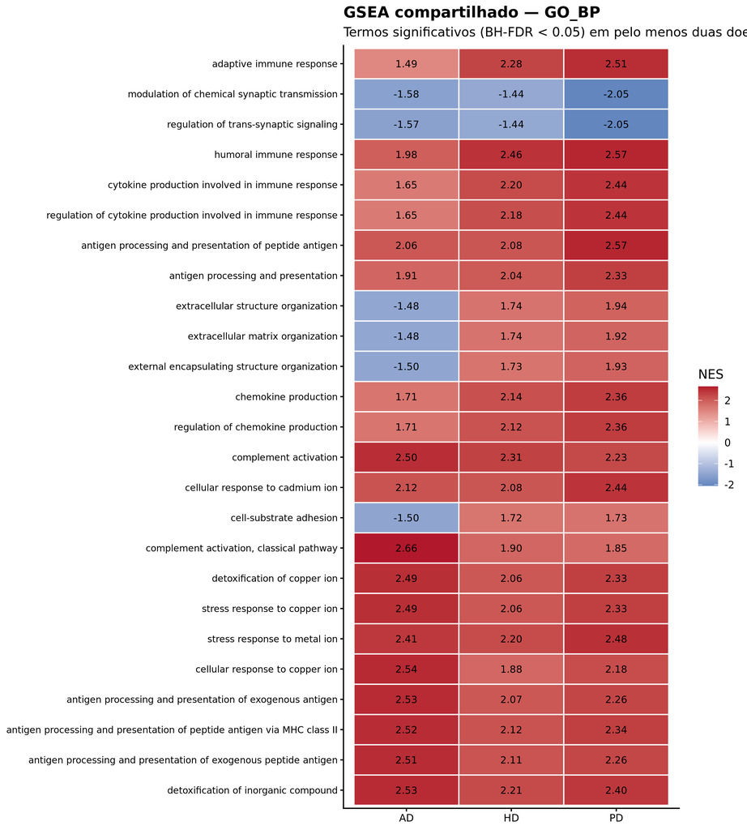

Termos GO Biological Process significativamente enriquecidos em pelo menos duas doenças e respectivos valores de NES.

A integração dos resultados de GSEA revelou convergência funcional substancial entre as três doenças.

Entre os processos que apresentaram **NES positivo nas três doenças** destacaram-se:

- resposta imune adaptativa;
- resposta imune humoral;
- produção e regulação de citocinas;
- produção e regulação de quimiocinas;
- ativação do complemento;
- via clássica do complemento;
- processamento e apresentação de antígenos;
- apresentação antigênica via MHC classe II;
- resposta e detoxificação relacionadas a metais.

Em contraste, processos relacionados à modulação da transmissão sináptica química e à regulação da sinalização trans-sináptica apresentaram **NES negativo nas três doenças**.

Esse resultado mostra que a convergência funcional pode ser mais evidente que a convergência baseada exclusivamente em DEGs individuais.

Essa observação é especialmente importante em AD. Apesar da ausência de DEGs pelo critério principal, conjuntos inteiros de genes envolvidos em processos imunológicos e neuronais apresentaram deslocamentos coordenados ao longo do ranking de expressão diferencial.

Também foram observados processos com comportamento divergente entre as doenças. `Extracellular matrix organization`, `extracellular structure organization`, `external encapsulating structure organization` e `cell-substrate adhesion`, por exemplo, apresentaram NES negativo em AD e positivo em HD e PD.

Esses resultados sugerem que, além de processos compartilhados, existem componentes funcionais potencialmente específicos ou diferencialmente regulados entre as doenças.

## 8.8 GSEA compartilhado — KEGG

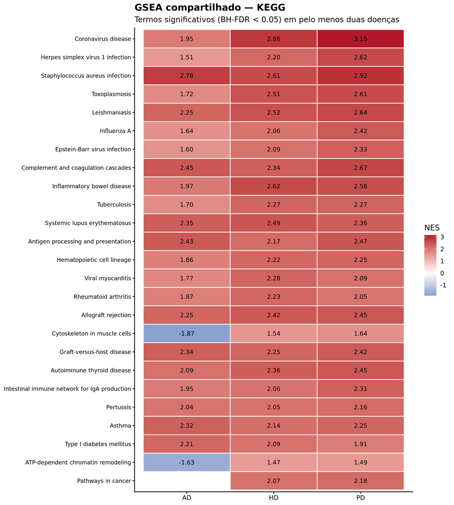

Vias KEGG significativamente enriquecidas em pelo menos duas doenças e respectivos valores de NES.

A integração das vias KEGG reforçou a existência de um eixo imunológico compartilhado.

Entre as vias com NES positivo nas três doenças destacaram-se:

- complemento e coagulação;
- processamento e apresentação de antígenos;
- linhagem hematopoiética;
- categorias relacionadas a respostas autoimunes;
- categorias relacionadas a respostas infecciosas.

Esses termos não devem ser interpretados como evidência de que as amostras apresentavam literalmente as doenças ou infecções indicadas pelos nomes das vias.

O enriquecimento decorre do compartilhamento de genes associados a complemento, MHC, citocinas, receptores, ativação leucocitária e mecanismos gerais de resposta imune.

Também foram observados padrões divergentes. `Cytoskeleton in muscle cells` e `ATP-dependent chromatin remodeling`, por exemplo, apresentaram NES negativo em AD e positivo em HD e PD.

Assim, a integração das vias KEGG reforça simultaneamente a presença de **mecanismos compartilhados** e **componentes específicos de cada doença**.

## 8.9 Síntese da integração transdiagnóstica

A integração transcriptômica revelou que a relação entre AD, HD e PD depende do nível de análise considerado.

**Comparabilidade transdiagnóstica.** A interseção dos universos testáveis resultou em 15.149 genes que puderam ser diretamente comparados nas três doenças.

**Convergência gênica.** A maior sobreposição ocorreu entre HD e PD. No universo pareado de 21.308 genes, foram encontrados 832 DEGs compartilhados, dos quais aproximadamente 99,0% apresentaram a mesma direção de efeito.

**Concordância global.** Os efeitos transcriptômicos de HD e PD apresentaram correlação positiva moderada (`Spearman ρ = 0,463`), enquanto AD apresentou associação fraca com HD e praticamente nula com PD no nível gene-a-gene.

**Convergência funcional.** Apesar das diferenças observadas no nível de genes individuais, as três doenças apresentaram enriquecimento positivo recorrente de processos relacionados à resposta imune, complemento, citocinas e apresentação antigênica, acompanhado por enriquecimento negativo de processos relacionados à transmissão e sinalização sináptica.

**Divergência funcional.** Processos relacionados à matriz extracelular, adesão e determinados componentes estruturais apresentaram direções diferentes entre AD e HD/PD, indicando que a convergência transdiagnóstica não é uniforme.

**Comparação nominal com a literatura.** Quando foi utilizado o critério `p < 0,05` e `|log2FC| > 1` nas listas completas, foram identificados 8 genes compartilhados pelas três doenças. Essa análise é comparativa e exploratória e não substitui o critério principal baseado em FDR.

Em conjunto, os resultados indicam que a convergência entre AD, HD e PD é mais robusta no nível de **processos biológicos coordenados** do que na sobreposição estrita de genes diferencialmente expressos.

# 9. Relação com a futura deconvolução celular

Um dos principais achados desta fase foi o contraste recorrente entre:

$$\text{assinaturas imunes/gliais} \uparrow$$

e

$$\text{assinaturas neuronais/sinápticas} \downarrow$$

Entretanto, bulk RNA-seq não permite determinar diretamente se esse padrão decorre de:

1. alteração da expressão dentro de um mesmo tipo celular;
2. alteração das proporções celulares presentes no tecido;
3. combinação dos dois mecanismos.

Por exemplo, maior expressão de genes imunes pode refletir aumento relativo de populações gliais/imunes, alteração do estado transcricional dessas células ou ambos.

Da mesma forma, redução de genes sinápticos pode refletir diminuição da fração neuronal, perda neuronal, alteração da função dos neurônios remanescentes ou combinação desses fatores.

A próxima etapa do projeto utilizará deconvolução celular para investigar essa questão, empregando uma referência de snRNA-seq e múltiplos algoritmos independentes.

# 10. Limitações

A interpretação desta fase deve considerar algumas limitações.

Primeiro, os datasets apresentam diferenças de tamanho amostral e disponibilidade de covariáveis. O modelo principal foi deliberadamente padronizado como `~ group`, de modo que fatores como idade, PMI, RIN e sexo não foram incorporados de forma uniforme em todos os estudos.

Segundo, AD apresentou baixo poder estatístico no nível de genes individuais, com apenas 17 amostras e ausência de DEGs após correção por múltiplos testes. Por isso, a contribuição de AD para a integração é mais evidente no nível funcional do GSEA.

Terceiro, GO e KEGG apresentam redundância entre termos. Diferentes categorias podem refletir parcialmente os mesmos genes ou módulos biológicos. Assim, a interpretação deve priorizar temas funcionais recorrentes e, quando necessário, os genes de `core_enrichment`.

Quarto, categorias KEGG nomeadas por infecções, doenças autoimunes ou outros contextos clínicos não devem ser interpretadas literalmente. O enriquecimento frequentemente decorre de genes imunológicos compartilhados entre essas categorias.

Quinto, bulk RNA-seq mistura sinais provenientes de múltiplos tipos celulares. Portanto, alterações funcionais observadas nesta fase não distinguem mudanças de composição celular de mudanças de expressão intrínseca.

Por fim, a fase atual utiliza matrizes de contagens disponibilizadas publicamente. Em uma etapa posterior, os dados serão reprocessados de forma padronizada a partir das leituras brutas, permitindo avaliar a influência das decisões de quantificação e processamento.

# 11. Conclusão da Fase 01

A análise padronizada das matrizes de contagens revelou comportamentos distintos no nível de genes individuais, mas convergência importante no nível funcional.

AD não apresentou DEGs segundo o critério principal, enquanto HD e PD apresentaram **2.227** e **2.801** DEGs, respectivamente.

No universo comum testável de **15.149 genes**, foram observados **536 DEGs compartilhados entre HD e PD**. Quando a comparação HD–PD foi realizada no universo pareado apropriado de **21.308 genes**, a sobreposição aumentou para **832 DEGs compartilhados**, dos quais **824** apresentaram a mesma direção do efeito. A correlação global dos efeitos entre HD e PD foi moderada (`Spearman ρ = 0,463`), enquanto as comparações envolvendo AD apresentaram associação fraca ou praticamente nula no nível gene-a-gene.

Apesar disso, a integração por GSEA revelou uma assinatura funcional transdiagnóstica consistente. Processos relacionados à resposta imune, citocinas, quimiocinas, complemento e apresentação antigênica apresentaram enriquecimento positivo recorrente, enquanto processos relacionados à transmissão e sinalização sináptica apresentaram enriquecimento negativo nas três doenças.

Assim, a principal conclusão da Fase 01 é que:

> **a convergência entre AD, HD e PD é mais evidente no nível de processos biológicos coordenados do que na sobreposição estrita de genes diferencialmente expressos.**

Esse achado fornece a base para a próxima etapa do projeto, na qual a deconvolução celular será utilizada para investigar em que medida o eixo imunológico positivo e o eixo neuronal negativo estão associados a alterações na composição celular do tecido ou a mudanças transcriptômicas dentro dos próprios tipos celulares.

# 12. Reprodutibilidade

Este relatório consome resultados produzidos sequencialmente pelos scripts:

```
00_audit_raw_data.R
01_prepare_metadata.R
02_prepare_counts.R
03_harmonize_genes.R
04_qc_counts.R
05_deseq2.R
06_pathway_enrichment.R
07_cross_disease_integration.R
```

O relatório não recalcula as análises principais; ele apenas lê as tabelas e figuras previamente produzidas pelo pipeline.